# **Analytic pipeline of DNA methylation data in R code**

Rosaria Tornisiello

6/29/2020

## Step 1

Loading of minfi, a R library that is used to perform the analysis and setting of the working directory. Loading of raw data with minfi and creation of an object called RGset storing the RGChannelSet data.

```r
rm(list=ls())
suppressMessages(library(minfi))
setwd("/home/rosaria/Desktop/DRD/Report_DRD/")
baseDir <- ("./Input_data")
targets <- read.metharray.sheet(baseDir)
```

```
## [1] "./Input_data/Samplesheet_report_2020.csv"
```

```r
RGset <- read.metharray.exp(targets = targets)
RGset
```

```
## class: RGChannelSet
## dim: 622399 8
## metadata(0):
## assays(2): Green Red
## rownames(622399): 10600313 10600322 ... 74810490 74810492
## rowData names(0):
## colnames(8): 5775278051_R01C01 5775278051_R04C02 ... 5930514035_R04C02
##   5930514035_R06C02
## colData names(7): Sample_Name Group ... Basename filenames
## Annotation
##   array: IlluminaHumanMethylation450k
##   annotation: ilmn12.hg19
```

## Step 2

Creation of the dataframes Red and Green to store the red and green fluorescences respectively.

```r
Red <- data.frame(getRed(RGset))
Green <- data.frame(getGreen(RGset))
```

## Step 3

Retrieving of red and green fluorescence for the address *59625465*.

```r
probe_red <- Red[rownames(Red)=="59625465",]
probe_green <- Green[rownames(Green)=="59625465",]

probe_red
```

```
##          X5775278051_R01C01 X5775278051_R04C02 X5775278078_R02C01
## 59625465              11585              14282              11253
##          X5775278078_R05C01 X5775278078_R05C02 X5930514034_R01C02
## 59625465              11494              11254              11152
##          X5930514035_R04C02 X5930514035_R06C02
## 59625465              11625              13019
```

```r
probe_green
```

```
##          X5775278051_R01C01 X5775278051_R04C02 X5775278078_R02C01
## 59625465                935                845                666
##          X5775278078_R05C01 X5775278078_R05C02 X5930514034_R01C02
## 59625465                785                652                306
##          X5930514035_R04C02 X5930514035_R06C02
## 59625465                584                668
```

| Sample | Red fluor | Green fluor | Type |
| --- | --- | --- | --- |
| X5775278051_R01C01 | 11585 | 935 | II |
| X5775278051_R04C02 | 14282 | 845 | II |
| X5775278078_R02C01 | 11253 | 666 | II |
| X5775278078_R05C01 | 11494 | 785 | II |
| X5775278078_R05C02 | 11254 | 652 | II |
| X5930514034_R01C02 | 11152 | 306 | II |
| X5930514035_R04C02 | 11625 | 584 | II |
| X5930514035_R06C02 | 13019 | 668 | II |

### Optional

Checking in the manifest file if the address corresponds to a Type I or a Type II probe.

```r
load('./Illumina450Manifest_clean.RData')
Illumina450Manifest_clean[Illumina450Manifest_clean$AddressA_ID=="59625465",]
```

```
##        IlmnID       Name AddressA_ID
## 42 cg01644972 cg01644972    59625465
##                                      AlleleA_ProbeSeq AddressB_ID
## 42 ATATCCTAATAAAATCTACTAAATATCAATCATTTAACCRTACCTCAACC
##    AlleleB_ProbeSeq Infinium_Design_Type Next_Base Color_Channel
## 42                                    II
##                                                                                                                Forward_Sequence
## 42 CAAACTCTCCGGTATCCTGATGGAGTCTACTAGGTGTCAGTCATTTGGCCGTGCCTCAGC[CG]AAGAGAGGCGGGGAAAAGCATCGTAATCAGCTGCGTCGCCTTTTGGTGACGCCAGAGAGT
##    Genome_Build CHR  MAPINFO                                          SourceSeq
## 42           37   Y 22737556 CGGCTGAGGCACGGCCAAATGACTGACACCTAGTAGACTCCATCAGGATA
##    Chromosome_36 Coordinate_36 Strand Probe_SNPs Probe_SNPs_10 Random_Loci
## 42             Y      21146944      R                                   NA
##    Methyl27_Loci UCSC_RefGene_Name UCSC_RefGene_Accession UCSC_RefGene_Group
## 42            NA            EIF1AY              NM_004681             TSS200
##     UCSC_CpG_Islands_Name Relation_to_UCSC_CpG_Island Phantom DMR Enhancer
## 42 chrY:22737825-22738052                     N_Shore                   NA
##             HMM_Island Regulatory_Feature_Name Regulatory_Feature_Group DHS
## 42 Y:21146854-21147440                                                   NA
```

As it is possible to see in the output, the address corresponds to a Type II probe so no color channel is specified. Moreover, there is a correspondence only for the address A and not for the address B since Type II never have it.

## Step 4

Creation of the object MSet.raw

```r
MSet.raw <- preprocessRaw(RGset)
MSet.raw
```

```
## class: MethylSet
## dim: 485512 8
## metadata(0):
## assays(2): Meth Unmeth
## rownames(485512): cg00050873 cg00212031 ... ch.22.47579720R
##   ch.22.48274842R
## rowData names(0):
## colnames(8): 5775278051_R01C01 5775278051_R04C02 ... 5930514035_R04C02
##   5930514035_R06C02
## colData names(7): Sample_Name Group ... Basename filenames
## Annotation
##   array: IlluminaHumanMethylation450k
##   annotation: ilmn12.hg19
## Preprocessing
##   Method: Raw (no normalization or bg correction)
##   minfi version: 1.34.0
##   Manifest version: 0.4.0
```

## Step 5

Performing the following quality checks:

- QCplot

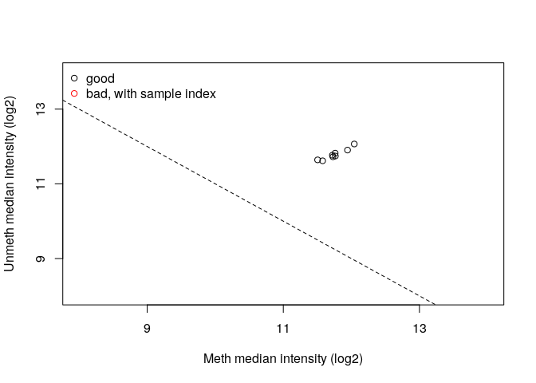

```r
qc <- getQC(MSet.raw)
plotQC(qc)
```

This Quality Control plot shows good results since all the points (samples) are localized above the diagonal.

- Checking the intensity of negative controls using minfi.

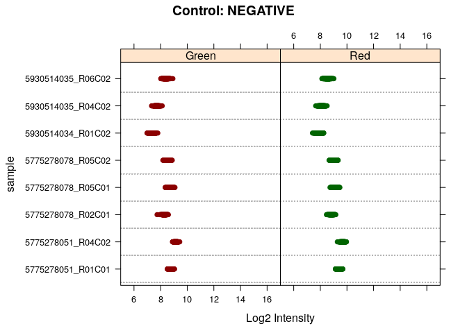

```r
controlStripPlot(RGset, controls="NEGATIVE")
```

The colors in this plot are inverted due to an error in the package. The colors written in the heading are correct. It is evident that all the negative controls have an intensity lower than 10 in log2 scale, so they are all good.

- Calculation of the detection pValues; for each sample, probes that have a detection p-value higher than the threshold 0.01 are computed and reported in the table below.

```r
detP <- detectionP(RGset)
failed <- detP>0.01
summary(failed)
```

```
##  5775278051_R01C01 5775278051_R04C02 5775278078_R02C01 5775278078_R05C01
##  Mode :logical     Mode :logical     Mode :logical     Mode :logical
##  FALSE:485189      FALSE:485252      FALSE:485200      FALSE:485027
##  TRUE :323         TRUE :260         TRUE :312         TRUE :485
##  5775278078_R05C02 5930514034_R01C02 5930514035_R04C02 5930514035_R06C02
##  Mode :logical     Mode :logical     Mode :logical     Mode :logical
##  FALSE:485047      FALSE:485389      FALSE:485452      FALSE:485363
##  TRUE :465         TRUE :123         TRUE :60          TRUE :149
```

| Sample | Failed positions |
| --- | --- |
| 5775278051_R01C01 | 323 |
| 5775278051_R04C02 | 260 |
| 5775278078_R02C01 | 312 |
| 5775278078_R05C01 | 485 |
| 5775278078_R05C02 | 465 |
| 5930514034_R01C02 | 123 |
| 5930514035_R04C02 | 60 |
| 5930514035_R06C02 | 149 |

## Step 6

Calculation of raw beta and M values and plotting of the densities of mean methylation values. First the samples are divided in DS and WT.

```r
csv <- read.csv("./Input_data/Samplesheet_report_2020.csv")
wt <- csv[csv$Group=="WT", "Basename"]
ds <- csv[csv$Group=="DS", "Basename"]
wtSet <- MSet.raw[,colnames(MSet.raw) %in% wt]
dsSet <- MSet.raw[,colnames(MSet.raw) %in% ds]
```

Beta and M are computed for both groups.

```r
wtBeta <- getBeta(wtSet)
wtM <- getM(wtSet)
dsBeta <- getBeta(dsSet)
dsM <- getM(dsSet)
```

Mean of beta and M are computed for both groups, discarding the NA values.

```r
mean_wtBeta <- apply(wtBeta,MARGIN=1,mean,na.rm=T)
mean_dsBeta <- apply(dsBeta,MARGIN=1,mean,na.rm=T)
mean_wtM <- apply(wtM,MARGIN=1,mean,na.rm=T)
mean_dsM <- apply(dsM,MARGIN=1,mean,na.rm=T)
```

The density distributions are computed for both beta and M.

```r
d_mean_wtBeta <- density(mean_wtBeta)
d_mean_dsBeta <- density(mean_dsBeta)
d_mean_wtM <- density(mean_wtM)
d_mean_dsM <- density(mean_dsM)
```

Finally the density plots are generated.

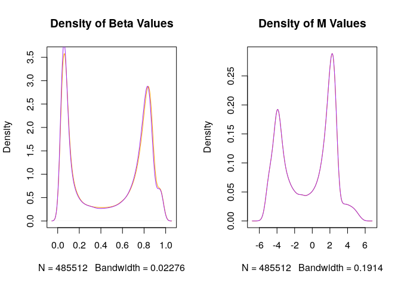

```r
par(mfrow=c(1,2))
plot(d_mean_wtBeta,main="Density of Beta Values",col="orange")
lines(d_mean_dsBeta,main="Density of Beta Values",col="purple")
plot(d_mean_dsM,main="Density of M Values",col="orange")
lines(d_mean_dsM,main="Density of M Values",col="purple")
```

## Step 7

Normalization of the data using the function preprocessSWAN and comparison between raw data and normalized data. The output is a plot with 6 panels in which, for both raw and normalized data, there are: density plots of beta mean values according to the chemistry of the probes; density plot of beta standard deviation values according to the chemistry of the probes; boxplot of beta values.

First, the Illumina450Manifest_clean is divided in two dataframes, containing only type I (dfI) or type II (dfII) probes:

```r
dfI <- Illumina450Manifest_clean[Illumina450Manifest_clean$Infinium_Design_Type=="I",]
dfI <- droplevels(dfI)
dfII <- Illumina450Manifest_clean[Illumina450Manifest_clean$Infinium_Design_Type=="II",]
dfII <- droplevels(dfII)
```

The beta matrix contains the beta values and the names of the probes are stored in the rownames. The following code subsets the beta matrix in order to retain only the rows whose name is in the first column of dfI or in the first column of dfII.

```r
beta <- getBeta(MSet.raw)
beta_I <- beta[rownames(beta) %in% dfI$IlmnID,]
beta_II <- beta[rownames(beta) %in% dfII$IlmnID,]
```

For each probe in the mean_of_beta_I and mean_of_beta_II matrices, the mean of beta values across the 8 samples and the density distribution of the 2 vectors of mean values are computed:

```r
mean_of_beta_I <- apply(beta_I,1,mean)
mean_of_beta_II <- apply(beta_II,1,mean)
d_mean_of_beta_I <- density(mean_of_beta_I,na.rm=T)
d_mean_of_beta_II <- density(mean_of_beta_II,na.rm=T)
```

The standard deviations of beta values are computed as well as their densities:

```r
sd_of_beta_I <- apply(beta_I,1,sd,na.rm=T)
sd_of_beta_II <- apply(beta_II,1,sd,na.rm=T)
d_sd_of_beta_I <- density(sd_of_beta_I)
d_sd_of_beta_II <- density(sd_of_beta_II)
```

Data are normalized using the preprocessSWAN function: Subset-quantile Within Array Normalisation (SWAN) for the Illumina Infinium HumanMethylation450 platform. It allows Infinium I and II type probes on a single array to be normalized together.

```r
preprocessSWAN_results <- preprocessSWAN(RGset)
```

The same process is repeated for the normalized data: calculation of beta, mean of beta, density of beta, standard deviation, mean of standard deviation and density of standard deviation

```r
beta_preprocessSWAN <- getBeta(preprocessSWAN_results)
beta_preprocessSWAN_I <- beta_preprocessSWAN[rownames(beta_preprocessSWAN) %in% dfI$IlmnID,]
beta_preprocessSWAN_II <- beta_preprocessSWAN[rownames(beta_preprocessSWAN) %in% dfII$IlmnID,]
mean_of_beta_preprocessSWAN_I <- apply(beta_preprocessSWAN_I,1,mean)
mean_of_beta_preprocessSWAN_II <- apply(beta_preprocessSWAN_II,1,mean)
d_mean_of_beta_preprocessSWAN_I <- density(mean_of_beta_preprocessSWAN_I,na.rm=T)
d_mean_of_beta_preprocessSWAN_II <- density(mean_of_beta_preprocessSWAN_II,na.rm=T)
sd_of_beta_preprocessSWAN_I <- apply(beta_preprocessSWAN_I,1,sd)
sd_of_beta_preprocessSWAN_II <- apply(beta_preprocessSWAN_II,1,sd)
d_sd_of_beta_preprocessSWAN_I <- density(sd_of_beta_preprocessSWAN_I,na.rm=T)
d_sd_of_beta_preprocessSWAN_II <- density(sd_of_beta_preprocessSWAN_II,na.rm=T)
```

Now it is possible to plot the results:

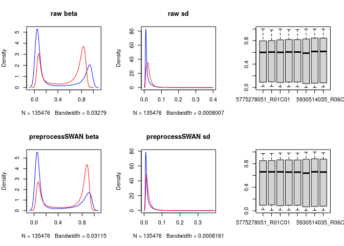

```r
par(mfrow=c(2,3))
plot(d_mean_of_beta_I,col="blue",main="raw beta")
lines(d_mean_of_beta_II,col="red")
plot(d_sd_of_beta_I,col="blue",main="raw sd")
lines(d_sd_of_beta_II,col="red")
boxplot(beta)
plot(d_mean_of_beta_preprocessSWAN_I,col="blue",main="preprocessSWAN beta")
lines(d_mean_of_beta_preprocessSWAN_II,col="red")
plot(d_sd_of_beta_preprocessSWAN_I,col="blue",main="preprocessSWAN sd")
lines(d_sd_of_beta_preprocessSWAN_II,col="red")
boxplot(beta_preprocessSWAN)
```

Comparing the density distributions of row beta and processSWAN beta means, it is evident that the type II probe peak is shifted towards the center and better aligned with the type I probe peak in the normalized data. Moreover, type I probes have higher density at low methylation levels and type II probes have higher density at high methylatilation levels. Regarding the standard deviation distributions, clearly, in the normalized data plot, the two peaks are more similar than in the raw data. Through the box plots it is easy to observe that the beta values fluctuate more across the 8 samples in the raw data than in the normalized data.

## Step 8

Performing a PCA analysis applying the function prcomp on the matrix of beta values obtained from normalized data in step 7.

```r
pca_results <- prcomp(t(beta_preprocessSWAN),scale=T)
summary(pca_results)
```

```
## Importance of components:
##                             PC1      PC2      PC3       PC4       PC5       PC6
## Standard deviation     461.0942 270.0638 232.9848 203.80133 189.30921 185.90864
## Proportion of Variance   0.4379   0.1502   0.1118   0.08555   0.07381   0.07119
## Cumulative Proportion    0.4379   0.5881   0.6999   0.78548   0.85929   0.93048
##                              PC7       PC8
## Standard deviation     183.71938 1.194e-12
## Proportion of Variance   0.06952 0.000e+00
## Cumulative Proportion    1.00000 1.000e+00
```

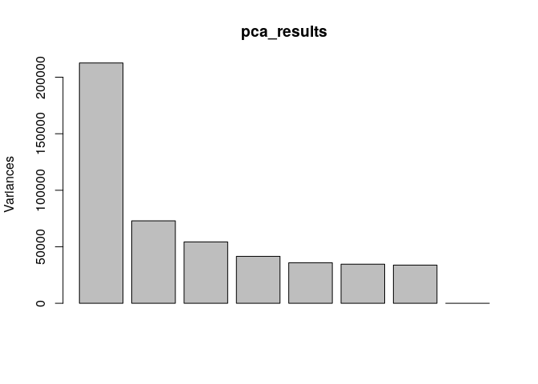

```r
plot(pca_results)
```

The PCA results plot reveals that the variance is almost equally distributed among the principal component going from 2 to 7; the first PC covers the higher proportion of variance while the 8th one contains a variance equal to 0.

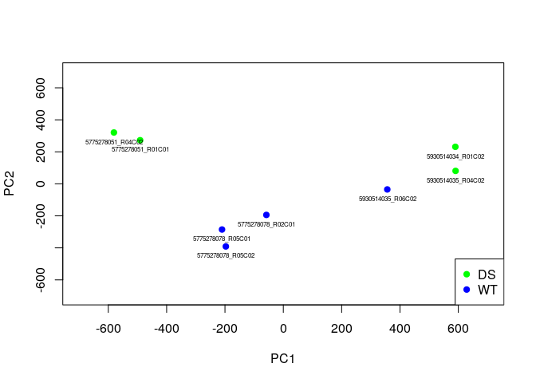

```r
pheno <- read.csv("./Input_data/Samplesheet_report_2020.csv",header=T, stringsAsFactors=T)
palette(c("green","blue"))
plot(pca_results$x[,1], pca_results$x[,2],cex=1,pch=19,col=pheno$Group,xlab="PC1",ylab="PC2",xlim=c(-700,700),ylim=c(-700,700))
text(pca_results$x[,1], pca_results$x[,2],labels=rownames(pca_results$x),cex=0.5,pos=1)
legend("bottomright",legend=levels(pheno$Group),col=c(1:nlevels(pheno$Group)),pch=19)
```

This plot shows that the samples DS and WT are well clusterized by the first two principal component. In particular, it seems that the DS samples are confined in the upper region of the plot (high PC2) while the WT samples are localized in the lower region of the plot (low PC2). Morevover, the samples are further clusterized in two groups according to PC1: both DS and WT samples are separated in a group with high PC1 and a second group with low PC1.

## Step 9

Using the matrix of normalized beta values generated in step 7, this step identifies differentially methylated probes between group DS and group WT using the Mann-Whytney non-parametric test.

```r
library(future.apply)
plan(multisession)
pheno <- read.csv("./Input_data/Samplesheet_report_2020.csv",header=T, stringsAsFactors=T)
My_mannwhitney_function <- function(x) {
  wilcox <- wilcox.test(x~ pheno$Group)
  return(wilcox$p.value)
}
pValues_wilcox <- future_apply(beta_preprocessSWAN, 1, My_mannwhitney_function)
```

Now it is possible to generate a dataframe with all the beta values and P-values

```r
final_wilcox <- data.frame(beta_preprocessSWAN, pValues_wilcox)
final_wilcox_sorted <- final_wilcox[order(final_wilcox$pValues_wilcox),]
summary(final_wilcox_sorted)
```

```
##  X5775278051_R01C01 X5775278051_R04C02 X5775278078_R02C01 X5775278078_R05C01
##  Min.   :0.01918    Min.   :0.009386   Min.   :0.01279    Min.   :0.01231
##  1st Qu.:0.09501    1st Qu.:0.099976   1st Qu.:0.08754    1st Qu.:0.09436
##  Median :0.66150    Median :0.661460   Median :0.66093    Median :0.65673
##  Mean   :0.50968    Mean   :0.511288   Mean   :0.51310    Mean   :0.51403
##  3rd Qu.:0.85108    3rd Qu.:0.852224   3rd Qu.:0.86516    3rd Qu.:0.86335
##  Max.   :0.97217    Max.   :0.973137   Max.   :0.98076    Max.   :0.98139
##  X5775278078_R05C02 X5930514034_R01C02 X5930514035_R04C02 X5930514035_R06C02
##  Min.   :0.01347    Min.   :0.005128   Min.   :0.007767   Min.   :0.009066
##  1st Qu.:0.09502    1st Qu.:0.067977   1st Qu.:0.073768   1st Qu.:0.078974
##  Median :0.65619    Median :0.639798   Median :0.661898   Median :0.658372
##  Mean   :0.51440    Mean   :0.504429   Mean   :0.513449   Mean   :0.513407
##  3rd Qu.:0.86277    3rd Qu.:0.873948   3rd Qu.:0.882222   3rd Qu.:0.878381
##  Max.   :0.98069    Max.   :0.995061   Max.   :0.998667   Max.   :0.987144
##  pValues_wilcox
##  Min.   :0.02857
##  1st Qu.:0.34286
##  Median :0.68571
##  Mean   :0.62575
##  3rd Qu.:0.88571
##  Max.   :1.00000
```

## Step 10

Application of multiple test correction, setting a significant threshold of 0.01. The first step is the creation of a vector storing the p-values (starting from the matrix in which the rows are ordered according the p-value, from the smallest to the largest). Then the Bonferroni correction and the Benjamini & Hochberg corrections are applied. Finally, a dataframe and a boxplot are generated.

```r
raw_pValues <- final_wilcox_sorted[,9]
corrected_pVal_Bonf <- p.adjust(raw_pValues,"bonferroni")
corrected_pVal_BH <- p.adjust(raw_pValues,"BH")
final_wilcox_corrected <- data.frame(final_wilcox_sorted, corrected_pVal_BH, corrected_pVal_Bonf)
summary(final_wilcox_corrected)
```

```
##  X5775278051_R01C01 X5775278051_R04C02 X5775278078_R02C01 X5775278078_R05C01
##  Min.   :0.01918    Min.   :0.009386   Min.   :0.01279    Min.   :0.01231
##  1st Qu.:0.09501    1st Qu.:0.099976   1st Qu.:0.08754    1st Qu.:0.09436
##  Median :0.66150    Median :0.661460   Median :0.66093    Median :0.65673
##  Mean   :0.50968    Mean   :0.511288   Mean   :0.51310    Mean   :0.51403
##  3rd Qu.:0.85108    3rd Qu.:0.852224   3rd Qu.:0.86516    3rd Qu.:0.86335
##  Max.   :0.97217    Max.   :0.973137   Max.   :0.98076    Max.   :0.98139
##  X5775278078_R05C02 X5930514034_R01C02 X5930514035_R04C02 X5930514035_R06C02
##  Min.   :0.01347    Min.   :0.005128   Min.   :0.007767   Min.   :0.009066
##  1st Qu.:0.09502    1st Qu.:0.067977   1st Qu.:0.073768   1st Qu.:0.078974
##  Median :0.65619    Median :0.639798   Median :0.661898   Median :0.658372
##  Mean   :0.51440    Mean   :0.504429   Mean   :0.513449   Mean   :0.513407
##  3rd Qu.:0.86277    3rd Qu.:0.873948   3rd Qu.:0.882222   3rd Qu.:0.878381
##  Max.   :0.98069    Max.   :0.995061   Max.   :0.998667   Max.   :0.987144
##  pValues_wilcox    corrected_pVal_BH corrected_pVal_Bonf
##  Min.   :0.02857   Min.   :0.6186    Min.   :1
##  1st Qu.:0.34286   1st Qu.:1.0000    1st Qu.:1
##  Median :0.68571   Median :1.0000    Median :1
##  Mean   :0.62575   Mean   :0.9741    Mean   :1
##  3rd Qu.:0.88571   3rd Qu.:1.0000    3rd Qu.:1
##  Max.   :1.00000   Max.   :1.0000    Max.   :1
```

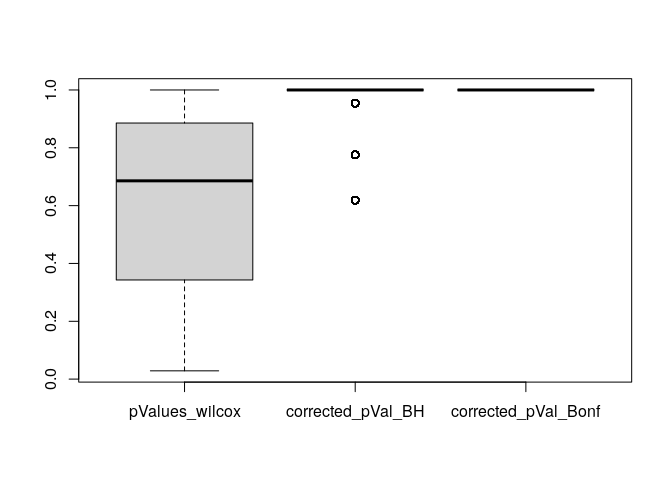

```r
boxplot(final_wilcox_corrected[,9:11])
```

The following code identifies differentially methylated probes considering nominal pValues, BH correction, and Bonferroni correction.

```r
dim(final_wilcox_sorted[final_wilcox_sorted$pValues_wilcox<=0.01,])
```

```
## [1] 0 9
```

```r
dim(final_wilcox_sorted[final_wilcox_sorted$corrected_pVal_BH<=0.01,])
```

```
## [1] 0 9
```

```r
dim(final_wilcox_sorted[final_wilcox_sorted$corrected_pVal_Bonf<=0.01,])
```

```
## [1] 0 9
```

The first number for each line of the output is the number of rows, so the number of differentially methylated probes considering the nominal p-value (in this case 0), the BH correction (0 probes) and the Bonferroni correction (0 probes).

## Step 11

Production of an heatmap of the top 100 differentially mehtylated probes. By default the function heatmap.2 uses the Euclidean distance as measure of distance and the complete linkage as linkage method for the hierarchical clustering. The first heatmap is generated using the default parameters: green represents the Down Syndrome and orange the Wild Type samples.

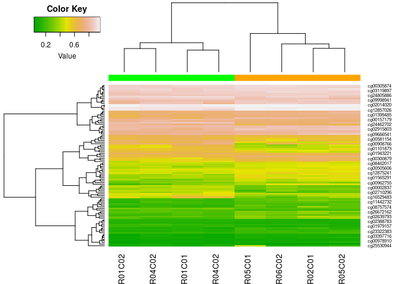

```r
library("gplots")
input_heatmap=as.matrix(final_wilcox_corrected[1:100,1:8])
colorbar <- c("green","green","orange","orange","orange","green","green","orange")
heatmap.2(input_heatmap,col=terrain.colors(100),Rowv=T,Colv=T,dendrogram="both",key=T,ColSideColors=colorbar,density.info="none",trace="none",scale="none",symm=F)
```

Changing the linkage method to single:

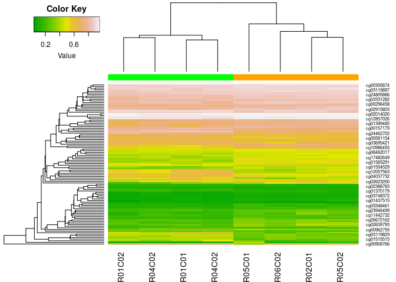

```r
heatmap.2(input_heatmap,col=terrain.colors(100),Rowv=T,Colv=T,hclustfun = function(x) hclust(x,method = 'single'),dendrogram="both",key=T,ColSideColors=colorbar,density.info="none",trace="none",scale="none",symm=F)
```

Finally, the heatmap related to the average linkage method:

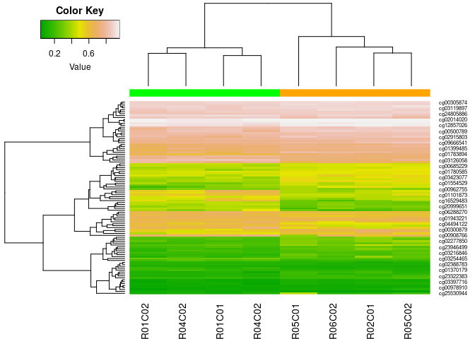

```r
heatmap.2(input_heatmap,col=terrain.colors(100),Rowv=T,Colv=T,hclustfun = function(x) hclust(x,method = 'average'),dendrogram="both",key=T,ColSideColors=colorbar,density.info="none",trace="none",scale="none",symm=F)
```

It is evident that in each sample the hierarchical clustering divides well group A and group B samples; in addition, some probes are hypermethylated in Group A compared to group B, others are hypomethylated. It is possible to compute the heatmaps changing also the distance measure, using Pearson or Spearman coefficients.

## Step 12

Production of a volcano plot and a Manhattan plot of the results of differential methylation analysis. - Volcano plot The first step is the calculation of the difference between the averge of group A values and the average of group B values. To this aim, first two matrixes containing the beta-values of group A and group B samples are created, and then the mean within each group for each row are computed.

```r
beta <- final_wilcox_corrected[,1:8]
beta_groupWT <- beta[,pheno$Group=="WT"]
mean_beta_groupWT <- apply(beta_groupWT,1,mean)
beta_groupDS <- beta[,pheno$Group=="DS"]
mean_beta_groupDS <- apply(beta_groupDS,1,mean)
```

Calculation of the difference between mean values:

```r
delta <- mean_beta_groupDS-mean_beta_groupWT
head(delta)
```

```
##   cg03695421   cg00685229   cg01370179   cg02639793   cg03748372   cg04037732
##  0.095564274 -0.057374402  0.033691809 -0.123919159 -0.008271363  0.138937538
```

Creation of a dataframe with two columns, one containing the delta values and the other with the -log10 of p-values:

```r
toVolcPlot <- data.frame(delta, -log10(final_wilcox_corrected$pValues_wilcox))
head(toVolcPlot)
```

```
##                   delta X.log10.final_wilcox_corrected.pValues_wilcox.
## cg03695421  0.095564274                                       1.544068
## cg00685229 -0.057374402                                       1.544068
## cg01370179  0.033691809                                       1.544068
## cg02639793 -0.123919159                                       1.544068
## cg03748372 -0.008271363                                       1.544068
## cg04037732  0.138937538                                       1.544068
```

Production of the plot:

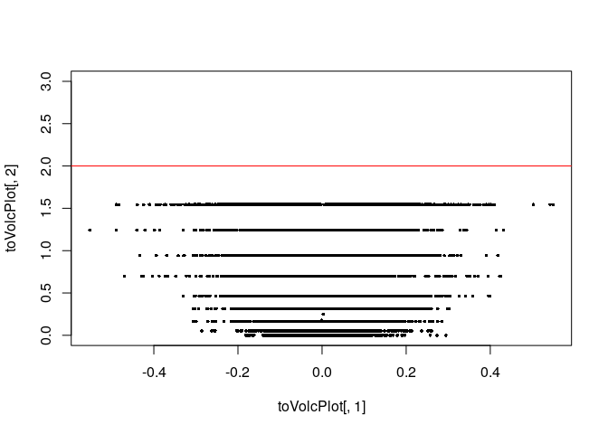

```r
plot(toVolcPlot[,1], toVolcPlot[,2],pch=16,cex=0.5, ylim = c(0,3))
abline(a=-log10(0.01),b=0,col="red")
```

In this plot, it is possible to see how the p-values are stratified at different levels and no point reaches the significance threshold (depicted in red). - Manhattan plot

```r
library(gap)
final_wilcox_corrected <- data.frame(rownames(final_wilcox_corrected),final_wilcox_corrected)
colnames(final_wilcox_corrected)[1] <- "IlmnID"
final_wilcox_corrected_annotated <- merge(final_wilcox_corrected, Illumina450Manifest_clean,by="IlmnID")
input_Manhattan <- data.frame(final_wilcox_corrected_annotated$CHR, final_wilcox_corrected_annotated$MAPINFO, final_wilcox_corrected_annotated$pValues_wilcox)
input_Manhattan$final_wilcox_corrected_annotated.CHR <- factor(input_Manhattan$final_wilcox_corrected_annotated.CHR,levels=c("1","2","3","4","5","6","7","8","9","10","11","12","13","14","15","16","17","18","19","20","21","22","X","Y"))
palette <- rainbow(24)
mhtplot(input_Manhattan,control=mht.control(colors=palette), ylim=c(0,3))
```

```
## Plotting points  1 - 46857
## Plotting points  46858 - 81667
## Plotting points  81668 - 106826
## Plotting points  106827 - 127290
## Plotting points  127291 - 151617
## Plotting points  151618 - 188228
## Plotting points  188229 - 218245
## Plotting points  218246 - 239195
## Plotting points  239196 - 249056
## Plotting points  249057 - 273444
## Plotting points  273445 - 302238
## Plotting points  302239 - 326777
## Plotting points  326778 - 339062
## Plotting points  339063 - 354140
## Plotting points  354141 - 369399
## Plotting points  369400 - 391368
## Plotting points  391369 - 419247
## Plotting points  419248 - 425169
## Plotting points  425170 - 450690
## Plotting points  450691 - 461069
## Plotting points  461070 - 465312
## Plotting points  465313 - 473864
## Plotting points  473865 - 485096
## Plotting points  485097 - 485512
```

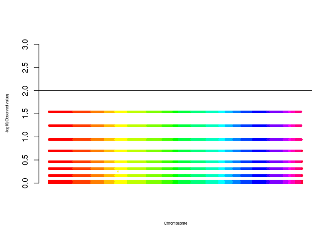

```r
axis(2,cex=0.5)
abline(a=-log10(0.01),b=0)
```

Both the Volcano plot and the Manhattan plot do not look like expected since the values are stratified and not spread in the plots, maybe because data underwent a non-parametric test (Mann-Whitney test)

## Optional

As DS is caused by the trisomy of chromosome 21, the following code plots the density of the methylation values of the probes mapping on chromosome 21.

```r
chr21 <- Illumina450Manifest_clean[Illumina450Manifest_clean$CHR=="21",]
chr21 <- droplevels(chr21)
dim(chr21)
```

```
## [1] 4243   33
```

Looking for the probes common to the Manifest and to the probes already identified after the normalization process:

```r
beta_WT_21 <- wtBeta[rownames(wtBeta) %in% chr21$IlmnID,]
beta_DS_21 <- dsBeta[rownames(dsBeta) %in% chr21$IlmnID,]
M_WT_21 <- wtM[rownames(wtM) %in% chr21$IlmnID,]
M_DS_21 <- dsM[rownames(dsM) %in% chr21$IlmnID,]
mean_beta_WT_21 <- apply(beta_WT_21,1,mean, na.omit=T)
mean_beta_DS_21 <- apply(beta_DS_21,1,mean, na.omit=T)
mean_M_WT_21 <- apply(M_WT_21,1,mean, na.omit=T)
mean_M_DS_21 <- apply(M_DS_21,1,mean, na.omit=T)
d_mean_beta_WT_21 <- density(mean_beta_WT_21, na.rm=T)
d_mean_beta_DS_21 <- density(mean_beta_DS_21, na.rm=T)
d_mean_M_WT_21 <- density(mean_M_WT_21, na.rm=T)
d_mean_M_DS_21 <- density(mean_M_DS_21, na.rm=T)
```

Now it is possible to produce the densities distribution plots of both Beta and M values relative to chromosome 21:

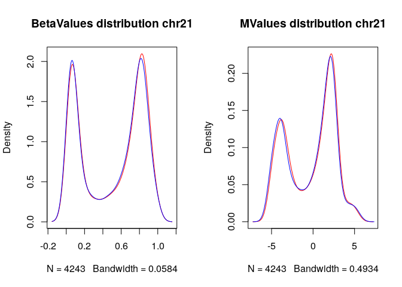

```r
par(mfrow = c(1,2))
plot(d_mean_beta_WT_21,col="red", main="BetaValues distribution chr21")
lines(d_mean_beta_DS_21, col = "blue")
plot(d_mean_M_WT_21, col="red", main="MValues distribution chr21")
lines(d_mean_M_DS_21, col="blue")
```

Looking at the distributions of both Beta and M values, it seems that there are not significative differences in the methylation levels of chromosome 21 between the wild type (red lines) and Down Syndrome (blue lines) samples.